# NBA Forbes Valuations

Robert Dinterman

June 15, 2016

Forbes released their [2015–16 NBA Franchise Valuations](http://www.forbes.com/nba-valuations/) in January of this year, which provides the best public data on the financial performance of NBA teams. In the [early 1990s](https://umich.app.box.com/s/41707f0b2619c0107b8b/1/320022877/3389744314/1), the now defunct [Financial World](https://en.wikipedia.org/wiki/Financial_World) started compiling data on the NBA until 1998 when the magazine went out of business. In 1999, Forbes picked up where Financial World left off and here we are. All data are available from [Rod Fort’s Sports Data](https://umich.app.box.com/s/41707f0b2619c0107b8b/1/320023265).

# Current Data Release

Hawks are valued at $825 million which ranks as 24th out of 30 teams where the average is $1,245 billion. Of this valuation, Forbes further breaks down as $346 million due to sport (partly NBA revenue sharing)[^1], $199 million due to the Atlanta market, $198 million from operating Philips Arena, and $87 million in “brand.” League average for these categories are $361 million, $466 million, $276 million, and $157 million respectively.

Forbes also reports the team had revenues last season of $142 million with $30 million of that coming from the gate[^2] and an operating income of $7 million. Forbes values the Hawks as holding 30% debt, or roughly $250 million, which would include arena debt that Forbes valued at around $112 million. That would appear to imply that Ressler’s group used some debt financing to purchase the team or inherited debt from the previous ownership group, it is not clear which is which or if both occurred.

> The Hawks are the only team where a majority stake was sold over the past 12 months. Tony Ressler, who co-founded investment managers Ares Management and Apollo Management, led a group who bid $730 million for the Hawks in April. Ressler also must relinquish arena revenue to pay off $112 million in bonds on Philips Arena, and he agreed to fund a new practice, which will cost more than $30 million.

> The Hawks are a club on the upswing after years of dysfunctional ownership. The new Fox Sports TV deal kicked off this season and is worth triple the prior pact on an annual basis. Atlanta Mayor Kasim Reed is backing a renovation of up to $250 million of Philips Arena that would include public funding. The team reached the Eastern Conference finals last year and is led by Coach of the Year Mike Budenholzer. Attendance jumped a league-leading 21% at Philips last year and the number of season ticket holders is up to 9,000 from 3,000. We value the team at $825 million.

> The Nets and Hawks transactions reflect the bifurcation of franchise values in recent years, with big market teams carrying significant premiums, particularly the largest markets like Los Angeles, where Steve Ballmer paid $2 billion for the Clippers in 2014. The top five teams are now worth $2.3 billion on average or three-and-a-half times the bottom five teams. Five years ago the multiple was only two times as much.

> *Source:* Forbes, [New York Knicks Head The NBA’s Most Valuable Teams At $3 Billion](http://www.forbes.com/sites/kurtbadenhausen/2016/01/20/new-york-knicks-head-the-nbas-most-valuable-teams-at-3-billion/)

A multitude of factors contribute towards the Hawks valuation and Kasim Reed pledging public support for the organization is certainly a factor. Another factor is their local cable TV deal with SportSouth. Reports have indicated that the Hawks previous annual revenues from FOX Sports paid around $12 million and that this almost tripled for the current to season to more than $30 million.

> The team’s current current cable deal with Fox Sports South (inherited from Turner South about eight years ago) pays in the neighborhood of $12 million a year on average. But the Hawks are working on a new deal with Fox that would likely begin with the 2016-17 season and average more than $30 million a season, according to sports media experts.

> *Source:* Forbes, [Sale Price Of Atlanta Hawks Getting Boost From New Cable TV Deal](http://www.forbes.com/sites/mikeozanian/2014/09/11/sale-price-of-atlanta-hawks-getting-boost-from-new-cable-tv-deal/)

Atlanta’s local cable TV deal was completed before this season, which helped bolster the franchise value. Recently, the Hawks TV ratings have taken [a 33% dip from last year](http://www.ajc.com/news/sports/basketball/hawks-tv-ratings-fall-after-record-season/nqQ3d/). Although this does not affect the current value of their TV contract, it may have an effect on future negotiations. But the decline in viewership is to be expected due to the differences in records from last year to this.

Oh, and the national TV deal which is split between other NBA teams has also had an impact on the valuation of the franchise. This effect is captured across all teams and is not unique to Atlanta. But let’s take a quick look at how Atlanta, and the rest of the NBA, has trended in a few important metrics since 1990.

# Historical Context

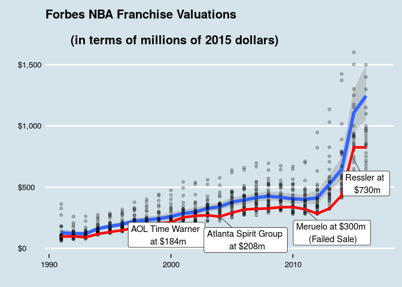

*(The red line represents the Atlanta Hawks while the blue line represents the average franchise value with a 95% error bar in grey. Each dot represents an NBA team. For the 2015 year, there are 7 teams with a franchise valuation of over $1.5 billion and are not shown in the graph: Brooklyn, Golden State, LA Clippers, Boston, Chicago, LA Lakers, and New York.)*

Eventually in [April of 2004](http://chronicle.augusta.com/stories/2004/04/01/nba_410725.shtml), the Atlanta Spirit Group, composed of 3 separate factions from Atlanta, Boston, and Washington DC, officially purchased the franchise at a [valued $208 million](http://www.bizjournals.com/atlanta/news/2015/03/27/koonin-hawks-sale-should-come-this-summer.html) although the purchase involved the operating rights to Philips Arena as well as the Atlanta Thrashers (RIP). The triumvirate was said to have fetched a sale price of $250 million.

The Atlanta Spirit Group announced a majority sale of the franchise to pizza tycoon Alex Meruelo in [August of 2011](http://latino.foxnews.com/latino/sports/2011/08/08/alex-meruelo-becomes-first-latino-nba-owner/) for a [reported $300 million](http://articles.latimes.com/2011/nov/04/sports/la-sp-meruelo-hawks-20111105) only to see the sale collapse in November of that year. It wasn’t until dissension within the ownership overflowed and reports surfaced of racially insensitive e-mails that Bruce Levenson announced in [September of 2014](http://www.usatoday.com/story/sports/nba/hawks/2014/09/07/bruce-levenson-racist-email-atlanta-owner-sell-team/15241591/) he would sell his shares of the Hawks, which eventually triggered a complete sale of the team. In early 2015, Tony Ressler formed a group which would emerge as purchasers of the Atlanta Hawks and operating rights to Philips Arena where the total purchase price approached $850 million but of which the Atlanta Hawks entity [accounted for $730 million](http://www.businessinsider.com/ressler-reportedly-buys-hawks-for-730m-2015-4). The official sale would not be completed until [June of 2015](http://www.nba.com/hawks/group-led-tony-ressler-completes-purchase-atlanta-hawks).

Throughout the time, the valuation of the franchise steadily rose, although the franchise’s value has consistently lagged behind others within the association.

## A Closer Look at Revenues

A course approximation of a businesses valuation can be apprised through revenues, costs, and profits. And Financial World/Forbes provides data on this for the whole set of NBA teams since 1990. We can look at yearly revenues across the NBA to see Atlanta’s standing with its business partners competitors.

[figure not shown]

The Hawks revenue flow has consistently lagged with respect to the rest of the NBA. At no point in time has Atlanta been above the mean in the NBA. Part of this is because of a slightly skewed distribution of revenues across teams, as can be seen that the top revenues each year is almost always comprised of the larger market teams (New York, Los Angeles, Chicago). Not surprisingly, these teams also consistently outpace the rest of the NBA in terms of cost of attendance.

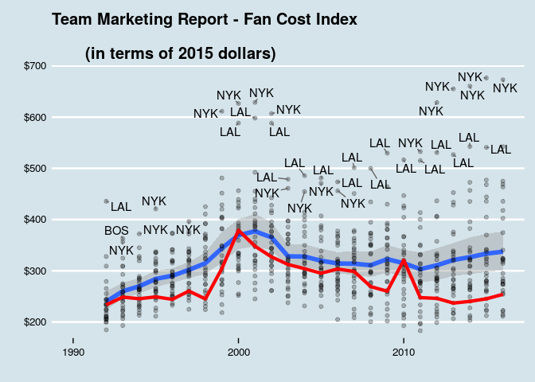

*(Fan Cost Index (FCI) is a metric compiled by [Team Marketing Report](https://www.teammarketing.com/). The FCI comprises the price of four average-price tickets, two cheapest beers, four cheapest soft drinks, four hot dogs, parking for one car, two game programs and two least-expensive, adult-size hats.)*

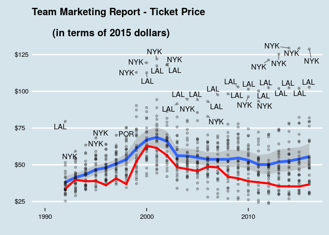

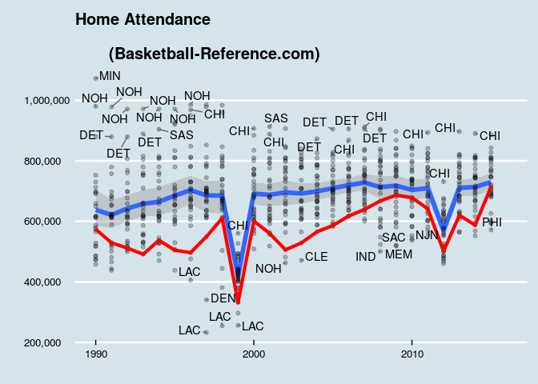

Changes in attendance does not necessarily lead to higher or lower revenues as this is only half of the equation. Price has a great deal of influence over the revenues generated for a franchise. And much like one would never evaluate the success or failure over a company by simply looking at how many people purchased a product, one should not necessarily evaluate the success or failure of a franchise over how many attended a game. But this is to be expected if one ignores the price.

## Player Costs[^3]

[figure not shown]

Player Costs, as measured by Financial World/Forbes, is a combination of player and coaches salary as paid in the current season. This may be a bit misleading if one looks only at the cap for the Hawks. For example, when Joe Johnson signed his [first infamous contract](http://espn.go.com/nba/columns/story?columnist=stein_marc&id=2120960) with Atlanta in 2005, it included a signing bonus of around $13.5 million with total compensation around $67.5 million. Joe was paid almost $23 million his first season and then $10 million, $10.8 million, $11.5 million, and finally $12.3 million. But as for what Joe’s cap hit looked like for the team, it was $12 million, $12.7 million, $13.5 million, $14.2 million, and finally $15 million.

In terms of amount spent on the team, it appears that the Hawks are not lagging in this aspect. With the exception of the period starting in 2005 until approximately 2008 where the [Hawks were constrained](http://www.sportsbusinessdaily.com/Journal/Issues/2005/09/20050919/Other-News/Atlanta-Partnership-Formed-In-8-Days-Dissolved-In-Sea-Of-Squabbles.aspx) by court ordered payroll restrictions caused by a lawsuit with then co-owner Steve Belkin, the Hawks have kept up with the Joneses with respect to payroll.

It should be noted that the NBA enforces a salary cap on team spending each year, which distorts the interpretation of league standing for payroll. Would Atlanta still maintain its standing as a middle of the road payroll team if no salary cap existed to restrain the spending of the league as a whole? This would be fodder for another discussion that I will not venture into at this time.

## Yearly Operating Income

[figure not shown]

To close out, here’s what the Operating Income looks like. In yet another business metric, the Hawks appear to lag behind others although this is not as consistent since between 2001 and 2007 the team appears to have operated much closer to the League Average than in the other metrics. The teams which dominate in this category appear to also dominate in the revenues metric as measured by Financial World/Forbes. This harks back to the salary cap, which puts a constraint on spending at both the league and team level.

# Closing

This article is meant to be a description of the performance of the Atlanta Hawks as measured by Financial World/Forbes since 1990. This is not meant to be an evaluation/critique of the business practices for the franchise. But I will add that it should not be interpreted that a franchise performs worse than its peers in the NBA is poorly run organization by any stretch just as the best performing company in a declining industry should not be evaluated as an outstanding company.

[^1]: The team does not receive $346 million per year in revenue sharing. The value attributed to revenue sharing is interpreted as the value of all future anticipated revenues shared.
[^2]: Gate revenue is generally made up of ticket sales, concessions, and merchandising.
[^3]: I do not fully endorse or trust these Forbes values, but these are the best data as a whole for evaluating the NBA. An example for why I do not fully believe this values is that the Hawks’ player costs for the 2014–15 season was $67 million. But if we look at their payroll it never exceeded $60 million that season.